# NESE Post-Breeding females: robustness of the number of PCs and clusters

Luis Huckstadt

2026-11-02

# 1 Purpose

This document accompanies `NESE_HCPC_PostBreeding.Rmd`. It does not replace the original analysis; it tests whether its two key choices — **5 principal components** and **3 clusters** — are justified and whether the resulting foraging strategies are robust. It is organised as:

1. Data checks (duplicates, skewness, multivariate outliers)
2. Number of PCs: Kaiser, cumulative variance, broken stick, parallel analysis, bootstrap eigenvalue CIs and bootstrap stability of the PC axes
3. Number of clusters: HCPC’s own criterion (without forcing `min = 3`), gap statistic, silhouette, Calinski–Harabasz, NbClust (Ward.D2), Gaussian mixture BIC, and a null-model test against a single multivariate Gaussian
4. Stability: whole-pipeline bootstrap Jaccard per cluster (Hennig 2007)
5. Sensitivity: number of PCs, isotopes in/out, transformations, clustering algorithm, outlier removal, leave-one-variable-out
6. nicheROVER: prior and dimensionality sensitivity
7. Summary of decisions and suggested Methods text

All random steps are seeded. Increase `N_BOOT`/`N_SIM` for the final run.

```r
library(dplyr)
library(tidyr)
library(ggplot2)
library(FactoMineR)
library(factoextra)
library(cluster)   # silhouette, clusGap
library(fpc)       # calinhara
library(mclust)    # Mclust, adjustedRandIndex
library(NbClust)
library(nicheROVER)

set.seed(20261028)

N_BOOT <- 500   # bootstrap replicates (eigenvalues, Jaccard)
N_PERM <- 1000  # parallel-analysis permutations
N_SIM  <- 500   # null-model simulations
K_MAX  <- 8

OUT <- "../results/robustness"
FIG <- "../figures/robustness"
dir.create(OUT, recursive = TRUE, showWarnings = FALSE)
dir.create(FIG, recursive = TRUE, showWarnings = FALSE)
```

# 2 Data

Variables are selected **by name**, not by column position (`[5:25]`), so the analysis cannot silently change if the data frame is re-ordered.

```r
ANALYSIS_VARS <- c(
  "d13C", "d15N", "MaxLat_degrees", "MinLon_degrees",
  "MedianDistToContShelf_km", "SdDistContShelf_km",
  "MesoEcoProportionShelf", "MesoEcoProportionCAC",
  "MesoEcoProportionSubArcticPac", "MesoEcoProportionNorthCPac",
  "Mean_Depth_m", "Mean_Depth_sd", "Mean_Duration_sec", "Mean_Duration_sd",
  "Pct_TransitDives", "Pct_ForagingDives", "Pct_DriftDives", "Pct_BenthicDives",
  "PctTripDiving", "DeepDayForageDivesMedian_m", "DeepNightForageDivesMedian_m")
ISO_VARS <- c("d13C", "d15N")

f.PCAdata.1 <- readRDS("../data/f.PCAdata.1.rds")
pb <- f.PCAdata.1 %>% filter(Trip == "PostBreeding") %>% as.data.frame()
rownames(pb) <- pb$TOPPID

stopifnot(all(ANALYSIS_VARS %in% names(pb)))
stopifnot(!anyDuplicated(pb$TOPPID))             # one trip per seal
stopifnot(all(complete.cases(pb[ANALYSIS_VARS])))
X <- pb[ANALYSIS_VARS]
n <- nrow(X); p <- ncol(X)
cat("n =", n, "seals; p =", p, "variables\n")
```

```
## n = 93 seals; p = 21 variables
```

```r
table(pb$ProcedureYear)
```

```
##
## 2008 2009 2010 2011 2012 2013 2014 2015 2016 2017
##    0   15   13   18   17   14   16    0    0    0
```

## 2.1 Skewness and multivariate outliers

PCA and Ward clustering are least-squares methods, so strongly skewed variables and extreme individuals can dominate them.

```r
skew <- function(x) { z <- (x - mean(x)) / sd(x); mean(z^3) }
sort(round(sapply(X, skew), 2))
```

```
##                  Mean_Depth_m             Pct_ForagingDives
##                         -1.28                         -0.37
##                 PctTripDiving MesoEcoProportionSubArcticPac
##                         -0.14                         -0.08
##                MinLon_degrees            SdDistContShelf_km
##                         -0.05                          0.01
##      MedianDistToContShelf_km              Pct_TransitDives
##                          0.02                          0.12
##                MaxLat_degrees    MesoEcoProportionNorthCPac
##                          0.24                          0.57
##    DeepDayForageDivesMedian_m                          d15N
##                          0.60                          0.73
##                          d13C                Pct_DriftDives
##                          0.85                          1.20
##              Mean_Duration_sd                 Mean_Depth_sd
##                          1.58                          1.65
##             Mean_Duration_sec  DeepNightForageDivesMedian_m
##                          1.69                          1.87
##          MesoEcoProportionCAC              Pct_BenthicDives
##                          2.10                          4.69
##        MesoEcoProportionShelf
##                          8.15
```

```r
pca0 <- prcomp(X, center = TRUE, scale. = TRUE)
S5 <- scale(pca0$x[, 1:5])
md2 <- rowSums(S5^2)                             # squared Mahalanobis in 5-PC space
cutoff <- qchisq(0.999, df = 5)
data.frame(TOPPID = names(md2), MD2 = round(md2, 1)) %>%
  arrange(desc(MD2)) %>% head(8) %>%
  mutate(beyond_0.999 = MD2 > cutoff)
```

```
##          TOPPID  MD2 beyond_0.999
## 2014015 2014015 55.7         TRUE
## 2012008 2012008 17.6        FALSE
## 2014003 2014003 17.2        FALSE
## 2011012 2011012 16.9        FALSE
## 2011021 2011021 15.0        FALSE
## 2014004 2014004 13.9        FALSE
## 2013017 2013017 11.8        FALSE
## 2014010 2014010 11.3        FALSE
```

# 3 How many principal components?

```r
zs <- function(X) scale(as.matrix(X))
eig_of <- function(Z) eigen(cor(Z), symmetric = TRUE, only.values = TRUE)$values

broken_stick <- function(p) sapply(1:p, function(k) sum(1 / (k:p)))

parallel_analysis <- function(Z, B = N_PERM, q = 0.95) {
  sims <- replicate(B, eig_of(apply(Z, 2, sample)))
  apply(sims, 1, quantile, probs = q)
}

boot_eigen <- function(Z, B = N_BOOT) {
  t(replicate(B, eig_of(Z[sample(nrow(Z), replace = TRUE), ])))
}

pc_table <- function(X) {
  Z <- zs(X); ev <- eig_of(Z); bt <- boot_eigen(Z)
  data.frame(PC = seq_along(ev), eigenvalue = ev,
             pct_var = 100 * ev / sum(ev), cum_pct = 100 * cumsum(ev) / sum(ev),
             broken_stick = broken_stick(ncol(Z)),
             PA_95 = parallel_analysis(Z),
             boot_lo = apply(bt, 2, quantile, 0.025),
             boot_hi = apply(bt, 2, quantile, 0.975))
}

pc_rules <- function(tab) c(
  `Kaiser (eigenvalue > 1)`   = sum(tab$eigenvalue > 1),
  `Cumulative variance >=75%` = which(tab$cum_pct >= 75)[1],
  `Cumulative variance >=80%` = which(tab$cum_pct >= 80)[1],
  `Broken stick`              = which(tab$eigenvalue <= tab$broken_stick)[1] - 1,
  `Parallel analysis (95%)`   = which(tab$eigenvalue <= tab$PA_95)[1] - 1)
```

```r
pc_all   <- pc_table(X)
pc_noiso <- pc_table(X[setdiff(ANALYSIS_VARS, ISO_VARS)])
round(head(pc_all, 10), 3)
```

```
##    PC eigenvalue pct_var cum_pct broken_stick PA_95 boot_lo boot_hi
## 1   1      6.447  30.701  30.701        3.645 2.174   6.141   7.276
## 2   2      3.800  18.097  48.798        2.645 1.918   3.228   4.677
## 3   3      2.790  13.285  62.083        2.145 1.746   2.138   3.409
## 4   4      1.965   9.355  71.438        1.812 1.607   1.654   2.319
## 5   5      1.434   6.828  78.266        1.562 1.497   1.158   1.748
## 6   6      0.913   4.347  82.612        1.362 1.400   0.789   1.258
## 7   7      0.846   4.030  86.642        1.195 1.304   0.605   0.954
## 8   8      0.715   3.403  90.046        1.053 1.217   0.464   0.768
## 9   9      0.529   2.519  92.564        0.928 1.137   0.324   0.590
## 10 10      0.353   1.681  94.245        0.816 1.065   0.252   0.482
```

```r
rules <- cbind(all_21 = pc_rules(pc_all), no_isotopes = pc_rules(pc_noiso))
rules
```

```
##                           all_21 no_isotopes
## Kaiser (eigenvalue > 1)        5           5
## Cumulative variance >=75%      5           5
## Cumulative variance >=80%      6           5
## Broken stick                   4           4
## Parallel analysis (95%)        4           4
```

```r
write.csv(pc_all, file.path(OUT, "PB_PC_retention_table.csv"), row.names = FALSE)
write.csv(rules,  file.path(OUT, "PB_PC_retention_rules.csv"))

# Can successive eigenvalues be distinguished? (bootstrap CIs overlap = no)
data.frame(PC = 1:8,
           separable_from_next = pc_all$boot_lo[1:8] > pc_all$boot_hi[2:9])
```

```
##   PC separable_from_next
## 1  1                TRUE
## 2  2               FALSE
## 3  3               FALSE
## 4  4               FALSE
## 5  5               FALSE
## 6  6               FALSE
## 7  7               FALSE
## 8  8               FALSE
```

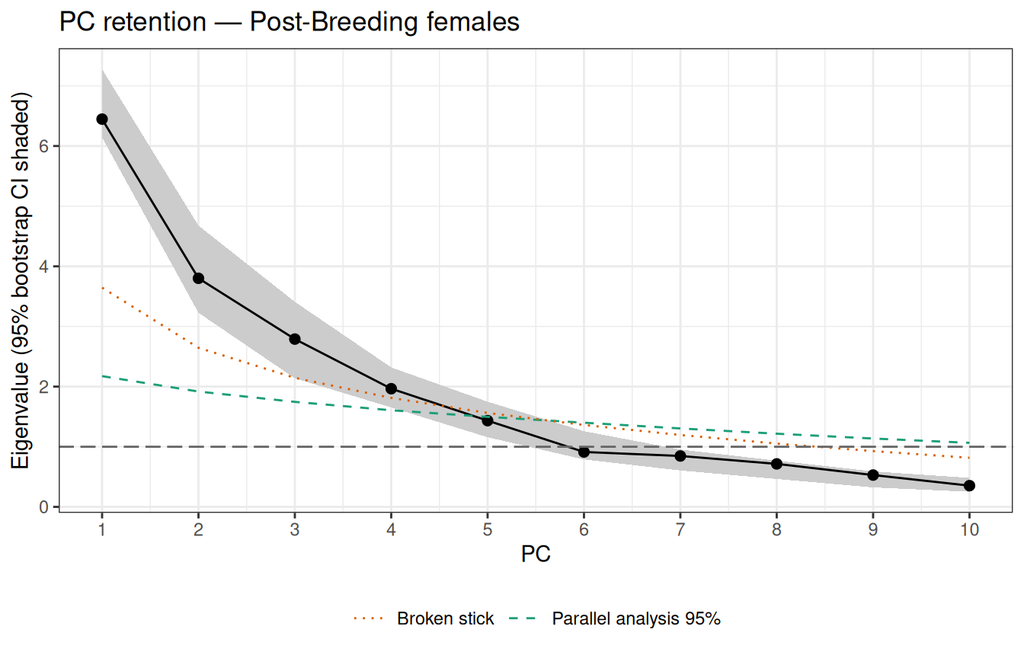

```r
g <- pc_all %>% filter(PC <= 10) %>%
  ggplot(aes(PC, eigenvalue)) +
  geom_ribbon(aes(ymin = boot_lo, ymax = boot_hi), fill = "grey80") +
  geom_line() + geom_point(size = 2) +
  geom_line(aes(y = PA_95, colour = "Parallel analysis 95%"), linetype = 2) +
  geom_line(aes(y = broken_stick, colour = "Broken stick"), linetype = 3) +
  geom_hline(yintercept = 1, colour = "grey40", linetype = 5) +
  scale_x_continuous(breaks = 1:10) +
  scale_colour_manual(values = c("#d95f02", "#1b9e77"), name = NULL) +
  labs(y = "Eigenvalue (95% bootstrap CI shaded)",
       title = "PC retention — Post-Breeding females") +
  theme_bw() + theme(legend.position = "bottom")
g
```

```r
ggsave(file.path(FIG, "PB_PC_retention.pdf"), g, width = 7, height = 4.5)
```

## 3.1 Are the individual PC axes stable?

Tucker’s congruence between full-data loadings and bootstrap loadings (> 0.85 = fair similarity, > 0.95 = equal; Lorenzo-Seva & ten Berge 2006). The subspace measure (mean squared cosine of principal angles) asks whether the *space* spanned by the first q PCs is stable even if individual axes rotate.

```r
congruence <- function(A, B) abs(crossprod(A, B)) /
  sqrt(outer(colSums(A^2), colSums(B^2)))
sub_cos2 <- function(A, B) {               # A, B: orthonormal p x q
  mean(svd(crossprod(A, B))$d^2)
}
V <- pca0$rotation
tuck <- matrix(NA, N_BOOT, 6); subsp <- matrix(NA, N_BOOT, 4,
                                               dimnames = list(NULL, paste0("q", 3:6)))
for (b in 1:N_BOOT) {
  Vb <- prcomp(X[sample(n, replace = TRUE), ], scale. = TRUE)$rotation
  tuck[b, ] <- apply(congruence(V[, 1:6], Vb[, 1:8]), 1, max)
  subsp[b, ] <- sapply(3:6, function(q) sub_cos2(V[, 1:q], Vb[, 1:q]))
}
data.frame(PC = 1:6,
           congruence_median = apply(tuck, 2, median),
           P_above_0.85 = colMeans(tuck > 0.85)) %>% round(2)
```

```
##   PC congruence_median P_above_0.85
## 1  1              0.98         1.00
## 2  2              0.94         0.84
## 3  3              0.86         0.52
## 4  4              0.89         0.65
## 5  5              0.84         0.46
## 6  6              0.71         0.13
```

```r
round(apply(subsp, 2, quantile, c(0.025, 0.5)), 3)
```

```
##         q3    q4    q5    q6
## 2.5% 0.647 0.731 0.783 0.797
## 50%  0.935 0.936 0.924 0.877
```

**Interpretation (results from the current data set).** Kaiser and the 75 % threshold give 5 PCs; the broken-stick model and parallel analysis — the two criteria that compare eigenvalues against what is expected without structure — both give **4**. PC5 (eigenvalue 1.43) falls below the 95 % parallel-analysis threshold (≈ 1.50) and its bootstrap CI overlaps both PC4 and PC6. PC1 and PC2 are stable axes; PCs 3–5 are not individually stable (they rotate into one another across bootstraps) although the 4–5-dimensional subspace is. Practical consequences:

# 4 How many clusters?

`hcpc_lite()` reproduces `FactoMineR::HCPC()` (Ward on PC coordinates, then k-means consolidation from the Ward centroids) quickly enough to be used inside bootstrap loops. The chunk checks that it gives the same answer.

```r
hcpc_lite <- function(S, k, consol = TRUE) {
  cl <- cutree(hclust(dist(S), method = "ward.D2"), k)
  if (!consol) return(cl)
  cen <- apply(S, 2, function(x) tapply(x, cl, mean))
  kmeans(S, centers = cen, iter.max = 100)$cluster
}
within_inertia <- function(S, kmax = 15) {
  h <- hclust(dist(S), method = "ward.D2")
  gains <- sort(h$height^2 / (2 * nrow(S)), decreasing = TRUE)
  sapply(1:kmax, function(k) sum(gains[k:length(gains)]))
}
# HCPC's automatic rule: minimise W(k)/W(k-1) over min..max
hcpc_ratio <- function(S, kmin = 2, kmax = 10) {
  W <- within_inertia(S, kmax + 1)
  setNames(W[kmin:kmax] / W[(kmin - 1):(kmax - 1)], kmin:kmax)
}
pc_scores <- function(X, npc) {
  pr <- prcomp(X, center = TRUE, scale. = TRUE)
  if (is.null(npc)) scale(X) else pr$x[, 1:npc, drop = FALSE]
}
```

```r
res.pca <- PCA(X, ncp = 5, graph = FALSE)
ref.hcpc <- HCPC(res.pca, nb.clust = 3, consol = TRUE, graph = FALSE)
REF <- as.integer(ref.hcpc$data.clust$clust)
table(REF)
```

```
## REF
##  1  2  3
## 39 48  6
```

```r
adjustedRandIndex(REF, hcpc_lite(res.pca$ind$coord, 3))  # should be 1
```

```
## [1] 1
```

## 4.1 HCPC’s own criterion — without forcing a minimum of 3

The original call `HCPC(..., min = 3, max = 10)` cannot return k = 2.

```r
S5 <- res.pca$ind$coord
q <- hcpc_ratio(S5, 2, 10)
round(q, 3)
```

```
##     2     3     4     5     6     7     8     9    10
## 0.703 0.769 0.848 0.857 0.891 0.907 0.898 0.894 0.915
```

```r
cat("HCPC suggests k =", names(which.min(q)), "when min = 2;",
    names(which.min(q[-1])), "when min = 3\n")
```

```
## HCPC suggests k = 2 when min = 2; 3 when min = 3
```

## 4.2 Internal indices across numbers of PCs

```r
k_grid <- do.call(rbind, lapply(2:8, function(npc) {
  S <- pc_scores(X, npc); d <- dist(S); qq <- hcpc_ratio(S, 2, K_MAX)
  do.call(rbind, lapply(2:K_MAX, function(k) {
    cl <- hcpc_lite(S, k)
    data.frame(nPC = npc, k = k, min_size = min(table(cl)),
               silhouette = mean(silhouette(cl, d)[, 3]),
               CH = calinhara(S, cl), HCPC_ratio = qq[as.character(k)],
               ARI_vs_original = adjustedRandIndex(REF, cl))
  }))
}))
write.csv(k_grid, file.path(OUT, "PB_k_grid.csv"), row.names = FALSE)
k_grid %>% filter(nPC %in% 4:5) %>% mutate(across(where(is.double), ~ round(.x, 3)))
```

```
##    nPC k min_size silhouette     CH HCPC_ratio ARI_vs_original
## 22   4 2       40      0.346 47.325      0.682           0.828
## 32   4 3        6      0.389 49.054      0.738           1.000
## 42   4 4        1      0.396 44.671      0.842           0.998
## 52   4 5        1      0.303 44.328      0.823           0.716
## 62   4 6        1      0.272 45.049      0.864           0.521
## 72   4 7        1      0.251 42.466      0.900           0.416
## 82   4 8        1      0.257 41.631      0.892           0.347
## 23   5 2       40      0.312 41.365      0.703           0.828
## 33   5 3        6      0.348 40.977      0.769           1.000
## 43   5 4        1      0.356 37.599      0.848           0.998
## 53   5 5        1      0.276 36.115      0.857           0.733
## 63   5 6        1      0.237 35.281      0.891           0.539
## 73   5 7        1      0.225 33.407      0.907           0.444
## 83   5 8        1      0.229 32.392      0.898           0.363
```

```r
k_grid %>% group_by(nPC) %>%
  summarise(best_silhouette = k[which.max(silhouette)],
            best_CH = k[which.max(CH)],
            HCPC_rule = k[which.min(HCPC_ratio)])
```

```
## # A tibble: 7 × 4
##     nPC best_silhouette best_CH HCPC_rule
##   <int>           <int>   <int>     <int>
## 1     2               3       8         2
## 2     3               4       3         2
## 3     4               4       3         2
## 4     5               4       2         2
## 5     6               4       2         2
## 6     7               4       2         2
## 7     8               5       2         2
```

Note `min_size`: from k = 4 onward the extra “cluster” is a single seal.

## 4.3 Gap statistic

```r
gap_list <- lapply(c(4, 5), function(npc) {
  S <- pc_scores(X, npc)
  gs <- clusGap(S, FUNcluster = function(x, k) list(cluster = hcpc_lite(x, k)),
                K.max = K_MAX, B = 200, spaceH0 = "scaledPCA", verbose = FALSE)
  print(gs, method = "Tibs2001SEmax")
  gs
})
```

```
## Clustering Gap statistic ["clusGap"] from call:
## clusGap(x = S, FUNcluster = function(x, k) list(cluster = hcpc_lite(x, k)), K.max = K_MAX, B = 200, spaceH0 = "scaledPCA", verbose = FALSE)
## B=200 simulated reference sets, k = 1..8; spaceH0="scaledPCA"
##  --> Number of clusters (method 'Tibs2001SEmax', SE.factor=1): 2
##          logW   E.logW       gap     SE.sim
## [1,] 4.727464 5.292599 0.5651349 0.02478066
## [2,] 4.472649 5.128685 0.6560358 0.02698849
## [3,] 4.335601 5.003628 0.6680275 0.02845924
## [4,] 4.280533 4.899836 0.6193024 0.02751399
## [5,] 4.181813 4.814961 0.6331484 0.02712102
## [6,] 4.089812 4.742045 0.6522329 0.02674212
## [7,] 4.025168 4.680909 0.6557411 0.02643809
## [8,] 3.953332 4.625979 0.6726463 0.02722743
## Clustering Gap statistic ["clusGap"] from call:
## clusGap(x = S, FUNcluster = function(x, k) list(cluster = hcpc_lite(x, k)), K.max = K_MAX, B = 200, spaceH0 = "scaledPCA", verbose = FALSE)
## B=200 simulated reference sets, k = 1..8; spaceH0="scaledPCA"
##  --> Number of clusters (method 'Tibs2001SEmax', SE.factor=1): 2
##          logW   E.logW       gap     SE.sim
## [1,] 4.785150 5.347580 0.5624305 0.02492939
## [2,] 4.562202 5.200194 0.6379922 0.02658843
## [3,] 4.442910 5.092086 0.6491762 0.02583193
## [4,] 4.389686 5.000727 0.6110409 0.02572688
## [5,] 4.307294 4.929151 0.6218568 0.02584876
## [6,] 4.233857 4.867388 0.6335310 0.02528276
## [7,] 4.176872 4.815917 0.6390452 0.02549005
## [8,] 4.118179 4.769419 0.6512398 0.02501841
```

## 4.4 NbClust (Ward.D2)

The original script used `method = "ward.D"` with Euclidean (unsquared) distances, which is not Ward’s criterion; `"ward.D2"` is.

```r
nb <- lapply(c(4, 5), function(npc)
  tryCatch(NbClust(pc_scores(X, npc), distance = "euclidean", min.nc = 2,
                   max.nc = K_MAX, method = "ward.D2", index = "all"),
           error = function(e) NULL))
```

```r
lapply(nb, function(x) if (!is.null(x)) table(x$Best.nc[1, ]))
```

```
## [[1]]
##
##  0  1  2  3  4  8
##  2  1  4 11  6  2
##
## [[2]]
##
##  0  1  2  3  4  5  8
##  2  1  5 10  4  2  2
```

## 4.5 Gaussian mixture models (BIC, including k = 1)

```r
bic4 <- mclustBIC(pc_scores(X, 4), G = 1:6)
bic5 <- mclustBIC(pc_scores(X, 5), G = 1:6)
summary(bic4); summary(bic5)
```

```
## Best BIC values:
##              EVE,3        VVE,3      EVE,4
## BIC      -1433.604 -1441.779065 -1446.0006
## BIC diff     0.000    -8.175278   -12.3968
```

```
## Best BIC values:
##              EVE,3        VVE,3       EVE,4
## BIC      -1748.823 -1750.102299 -1759.39463
## BIC diff     0.000    -1.279414   -10.57175
```

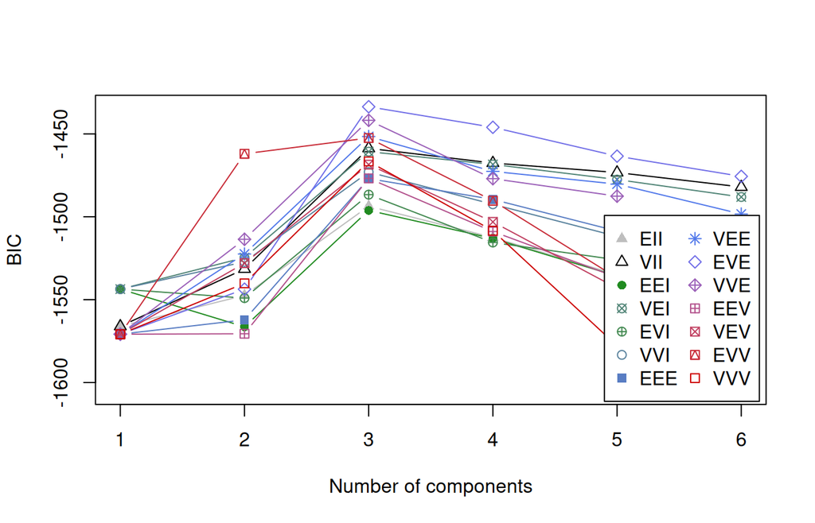

```r
plot(bic4)
```

## 4.6 Is there cluster structure at all? Null-model test

Data are simulated from a single multivariate Gaussian with the observed PC variances (i.e. no clusters), clustered with the same pipeline, and compared with the observed silhouette and CH.

```r
null_test <- function(npc, k, B = N_SIM) {
  S <- pc_scores(X, npc); cl <- hcpc_lite(S, k); sds <- apply(S, 2, sd)
  obs <- c(sil = mean(silhouette(cl, dist(S))[, 3]), CH = calinhara(S, cl))
  sim <- t(replicate(B, {
    Y <- sapply(sds, function(s) rnorm(nrow(S), 0, s)); cy <- hcpc_lite(Y, k)
    c(sil = mean(silhouette(cy, dist(Y))[, 3]), CH = calinhara(Y, cy))
  }))
  data.frame(nPC = npc, k = k, obs_sil = obs["sil"], p_sil = mean(sim[, "sil"] >= obs["sil"]),
             obs_CH = obs["CH"], p_CH = mean(sim[, "CH"] >= obs["CH"]))
}
null_res <- do.call(rbind, lapply(c(4, 5), function(npc)
  do.call(rbind, lapply(2:4, function(k) null_test(npc, k)))))
rownames(null_res) <- NULL
round(null_res, 3)
```

```
##   nPC k obs_sil p_sil obs_CH  p_CH
## 1   4 2   0.346     0 47.325 0.040
## 2   4 3   0.389     0 49.054 0.000
## 3   4 4   0.396     0 44.671 0.000
## 4   5 2   0.312     0 41.365 0.052
## 5   5 3   0.348     0 40.977 0.000
## 6   5 4   0.356     0 37.599 0.000
```

# 5 Stability: whole-pipeline bootstrap Jaccard

Each replicate resamples seals with replacement and re-runs **everything** (standardisation, PCA, PC retention, Ward + consolidation). For each original cluster the maximum Jaccard similarity to any bootstrap cluster is recorded. Hennig (2007): mean Jaccard < 0.5 = dissolved, 0.6–0.75 = pattern, > 0.75 = stable, > 0.85 = highly stable.

```r
boot_jaccard <- function(npc, k, vars = ANALYSIS_VARS, B = N_BOOT) {
  ref <- hcpc_lite(pc_scores(X[vars], npc), k)
  J <- matrix(NA, B, k)
  for (b in 1:B) {
    ix <- unique(sample(n, replace = TRUE))
    cb <- hcpc_lite(pc_scores(X[ix, vars], npc), k)
    for (c in 1:k) {
      A <- ix[ref[ix] == c]
      if (length(A)) J[b, c] <- max(sapply(unique(cb), function(j) {
        Bj <- ix[cb == j]; length(intersect(A, Bj)) / length(union(A, Bj)) }))
    }
  }
  data.frame(nPC = npc, k = k, cluster = 1:k, n = as.vector(table(ref)),
             jaccard_mean = colMeans(J, na.rm = TRUE),
             P_dissolved = colMeans(J < 0.5, na.rm = TRUE))
}
jac <- do.call(rbind, lapply(c(4, 5), function(npc)
  do.call(rbind, lapply(2:4, function(k) boot_jaccard(npc, k)))))
write.csv(jac, file.path(OUT, "PB_bootstrap_jaccard.csv"), row.names = FALSE)
jac %>% mutate(across(c(jaccard_mean, P_dissolved), ~ round(.x, 2)))
```

```
##    nPC k cluster  n jaccard_mean P_dissolved
## 1    4 2       1 53         0.99        0.00
## 2    4 2       2 40         0.99        0.00
## 3    4 3       1 48         0.98        0.00
## 4    4 3       2 39         0.99        0.00
## 5    4 3       3  6         0.89        0.08
## 6    4 4       1 48         0.86        0.01
## 7    4 4       2 39         0.91        0.01
## 8    4 4       3  5         0.85        0.09
## 9    4 4       4  1         0.87        0.11
## 10   5 2       1 53         0.99        0.00
## 11   5 2       2 40         0.99        0.00
## 12   5 3       1 48         0.97        0.00
## 13   5 3       2 39         0.99        0.00
## 14   5 3       3  6         0.88        0.08
## 15   5 4       1 48         0.87        0.01
## 16   5 4       2 39         0.93        0.00
## 17   5 4       3  5         0.86        0.06
## 18   5 4       4  1         0.95        0.03
```

# 6 Sensitivity of the partition

Each scenario is compared with the original solution (5 PCs, k = 3) by the adjusted Rand index (ARI = 1: identical partition). `coastal` tracks whether the six seals of the small cluster remain together.

```r
coastal_ids <- which(REF == as.integer(names(which.min(table(REF)))))
coastal_kept <- function(cl) {
  best <- names(which.max(table(cl[coastal_ids])))
  sprintf("%d/6 in group of %d", max(table(cl[coastal_ids])), sum(cl == best))
}
log_skewed <- function(X) {
  v <- intersect(c("MesoEcoProportionShelf", "Pct_BenthicDives", "Mean_Duration_sec",
                   "Mean_Duration_sd", "Mean_Depth_sd", "Pct_DriftDives",
                   "MesoEcoProportionCAC"), names(X))
  X[v] <- lapply(X[v], function(x) log(x + min(x[x > 0]) / 2)); X
}
scen <- list(
  "nPC=2, k=3"  = hcpc_lite(pc_scores(X, 2), 3),
  "nPC=3, k=3"  = hcpc_lite(pc_scores(X, 3), 3),
  "nPC=4, k=3"  = hcpc_lite(pc_scores(X, 4), 3),
  "nPC=6, k=3"  = hcpc_lite(pc_scores(X, 6), 3),
  "nPC=8, k=3"  = hcpc_lite(pc_scores(X, 8), 3),
  "all variables (no PCA), k=3" = hcpc_lite(pc_scores(X, NULL), 3),
  "nPC=4, k=2"  = hcpc_lite(pc_scores(X, 4), 2),
  "Ward, no consolidation" = hcpc_lite(pc_scores(X, 5), 3, consol = FALSE),
  "k-means (100 starts)" = kmeans(pc_scores(X, 5), 3, nstart = 100)$cluster,
  "Gaussian mixture (VVI)" = Mclust(pc_scores(X, 5), G = 3, modelNames = "VVI")$classification,
  "No isotopes, nPC=4" = hcpc_lite(pc_scores(X[setdiff(ANALYSIS_VARS, ISO_VARS)], 4), 3),
  "Log-transformed skewed vars, nPC=4" = hcpc_lite(pc_scores(log_skewed(X), 4), 3),
  "Rank-transformed, nPC=4" = hcpc_lite(pc_scores(as.data.frame(lapply(X, rank)), 4), 3)
)
sens <- data.frame(scenario = names(scen),
                   sizes = sapply(scen, function(cl) paste(sort(table(cl), TRUE), collapse = "/")),
                   ARI = sapply(scen, function(cl) round(adjustedRandIndex(REF, cl), 3)),
                   coastal = sapply(scen, coastal_kept), row.names = NULL)

# Drop the most extreme individual
md_out <- names(which.max(md2))
keep <- rownames(X) != md_out
cl_drop <- hcpc_lite(pc_scores(X[keep, ], 5), 3)
sens <- rbind(sens, data.frame(scenario = paste("Drop outlier", md_out),
  sizes = paste(sort(table(cl_drop), TRUE), collapse = "/"),
  ARI = round(adjustedRandIndex(REF[keep], cl_drop), 3), coastal = "-"))
write.csv(sens, file.path(OUT, "PB_sensitivity.csv"), row.names = FALSE)
sens
```

```
##                              scenario    sizes   ARI            coastal
## 1                          nPC=2, k=3  47/40/6 0.959  6/6 in group of 6
## 2                          nPC=3, k=3  48/39/6 1.000  6/6 in group of 6
## 3                          nPC=4, k=3  48/39/6 1.000  6/6 in group of 6
## 4                          nPC=6, k=3  48/39/6 1.000  6/6 in group of 6
## 5                          nPC=8, k=3  48/39/6 1.000  6/6 in group of 6
## 6         all variables (no PCA), k=3  48/39/6 1.000  6/6 in group of 6
## 7                          nPC=4, k=2    53/40 0.828 6/6 in group of 53
## 8              Ward, no consolidation  49/38/6 0.881  6/6 in group of 6
## 9                k-means (100 starts)  48/39/6 1.000  6/6 in group of 6
## 10             Gaussian mixture (VVI)  53/34/6 0.517  6/6 in group of 6
## 11                 No isotopes, nPC=4  48/39/6 1.000  6/6 in group of 6
## 12 Log-transformed skewed vars, nPC=4  48/39/6 1.000  6/6 in group of 6
## 13            Rank-transformed, nPC=4 39/30/24 0.620 6/6 in group of 24
## 14               Drop outlier 2014015  48/39/5 1.000                  -
```

```r
# Leave-one-variable-out
lovo <- sapply(ANALYSIS_VARS, function(v)
  adjustedRandIndex(REF, hcpc_lite(pc_scores(X[setdiff(ANALYSIS_VARS, v)], 5), 3)))
sort(round(lovo, 3))
```

```
##    MesoEcoProportionNorthCPac                MaxLat_degrees
##                         0.842                         0.975
##          MesoEcoProportionCAC MesoEcoProportionSubArcticPac
##                         0.975                         0.975
##              Pct_BenthicDives                          d13C
##                         0.975                         1.000
##                          d15N                MinLon_degrees
##                         1.000                         1.000
##      MedianDistToContShelf_km            SdDistContShelf_km
##                         1.000                         1.000
##        MesoEcoProportionShelf                  Mean_Depth_m
##                         1.000                         1.000
##                 Mean_Depth_sd             Mean_Duration_sec
##                         1.000                         1.000
##              Mean_Duration_sd              Pct_TransitDives
##                         1.000                         1.000
##             Pct_ForagingDives                Pct_DriftDives
##                         1.000                         1.000
##                 PctTripDiving    DeepDayForageDivesMedian_m
##                         1.000                         1.000
##  DeepNightForageDivesMedian_m
##                         1.000
```

## 6.1 Cluster profiles on the original variables

Separation on clustering variables is descriptive, not independent validation.

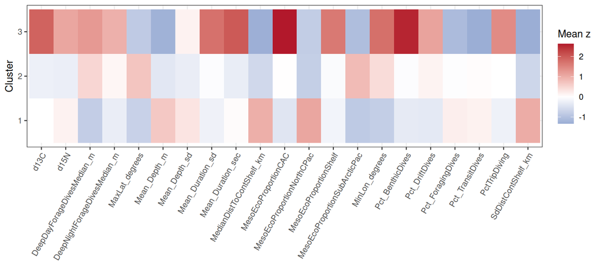

```r
prof <- data.frame(scale(X), cluster = factor(REF)) %>%
  pivot_longer(-cluster) %>% group_by(cluster, name) %>%
  summarise(mean_z = mean(value), .groups = "drop")
gp <- ggplot(prof, aes(name, cluster, fill = mean_z)) + geom_tile() +
  scale_fill_gradient2(low = "#2166ac", high = "#b2182b") + theme_bw() +
  theme(axis.text.x = element_text(angle = 60, hjust = 1)) +
  labs(x = NULL, y = "Cluster", fill = "Mean z")
gp
```

```r
ggsave(file.path(FIG, "PB_cluster_profiles.pdf"), gp, width = 10, height = 4)
table(cluster = REF, year = pb$ProcedureYear)
```

```
##        year
## cluster 2008 2009 2010 2011 2012 2013 2014 2015 2016 2017
##       1    0    5    6   11    8    7    2    0    0    0
##       2    0   10    7    6    8    6   11    0    0    0
##       3    0    0    0    1    1    1    3    0    0    0
```

# 7 nicheROVER: prior and dimensionality

The original script used `Psi <- crossprod(matrix(rnorm(d^2), d, d))` without a seed. This is an **informative, random** prior on Σ: it changes on every run and is added to the cluster’s scatter matrix. With n = 6 in 5 dimensions the prior dominates the posterior for the small cluster. Here the default (non-informative) `niw.post` prior is compared with several random draws.

```r
niche_size_med <- function(Y, Psi = NULL, alpha = 0.75, ns = 2000) {
  post <- if (is.null(Psi)) niw.post(nsamples = ns, X = Y)
          else niw.post(nsamples = ns, X = Y, Psi = Psi)
  median(apply(post$Sigma, 3, niche.size, alpha = alpha))
}
prior_check <- do.call(rbind, lapply(c(4, 5), function(d) {
  S <- res.pca$ind$coord[, 1:d]
  do.call(rbind, lapply(sort(unique(REF)), function(c) {
    Y <- S[REF == c, , drop = FALSE]
    rnd <- replicate(20, niche_size_med(Y, crossprod(matrix(rnorm(d^2), d, d))))
    data.frame(d = d, cluster = c, n = nrow(Y),
               default_prior = niche_size_med(Y),
               random_Psi_min = min(rnd), random_Psi_max = max(rnd))
  }))
}))
prior_check %>% mutate(across(4:6, ~ round(.x, 1)))
```

```
##   d cluster  n default_prior random_Psi_min random_Psi_max
## 1 4       1 39         169.4          181.3          228.3
## 2 4       2 48         235.5          247.4          295.3
## 3 4       3  6          26.1          122.1          806.5
## 4 5       1 39         785.4          964.6         1293.9
## 5 5       2 48         871.4          933.7         1337.8
## 6 5       3  6          21.3          404.9         5452.0
```

Recommendations for the niche analysis:

- Use the default prior (`niw.post(nsamples, X)`) or a documented, fixed prior, and `set.seed()` before each call.
- Use the number of PCs justified above (4), and report that niche size and overlap are rotation-invariant (so the PC-axis instability does not affect them) but that their *scale* depends on d.
- Treat the coastal cluster (n = 6) cautiously: with n − 1 = d the covariance is barely identifiable. Report its niche metrics with that caveat, or compare niches in a lower-dimensional space (e.g. PC1–PC2, or δ¹³C–δ¹⁵N) where n ≫ d.

# 8 Summary and suggested Methods text

**Number of PCs.** *We retained principal components using Horn’s parallel analysis (1,000 column permutations, 95th percentile) and the broken-stick model, which both supported four components (71.4 % of variance); Kaiser’s criterion and a 75 % cumulative-variance threshold suggested five. Because cluster assignments were identical for any number of retained components between three and all 21 standardised variables (ARI = 1), this choice did not affect the identification of foraging strategies.*

(Numbers in italics are from the run of 2026-10-28; update them from the knitted output.)